# L24 LAB 20 (MD)

AnaGSanjuanM

2023-02-22

Hecho con gusto por Carla Carolina Pérez Hernández (UAEH)

LABORATORIO - Gráficos en R con ggplot2

faceting (romper un gráfica en varias dentro de una cuadrícula)

———————-LABORATORIO 20—————————-

———–Alumna: Ana Grisel Sanjuan Merida———————

Instalando paquete

install.packages(“ggplot2”)

Cargar libreria ggplot2

```r
library(ggplot2)
```

Buscar df

```r
file.choose()
```

```
## [1] "C:\\Users\\Lenovo\\Documents\\GitHub\\LAB-20\\L20 Input\\PARA FACETING.csv"
```

Leer base al crear un data frame. Recibirá el nombre de densidad_verde. Se coloca signo de asignación (teclear: alt -). Añadimos read.csv. Dentro del paréntesis colocamos la ruta (de comillas a comillas) del archivo recien seleccionado.

```r
densidad_verde <- read.csv("C:\\Users\\Lenovo\\Documents\\GitHub\\LAB-20\\L20 Input\\PARA FACETING.csv")
```

Ver nombres

Anotamos names. Dentro del paréntesis, colocar el nombre del data frame creado.

```r
names(densidad_verde)
```

```
##  [1] "ID"           "datamex_code" "Product"      "PCI.2018"     "N_PCI.2018"
##  [6] "Region"       "rca_bin"      "DENSITY"      "GCI_2018"     "GP_SINVCR"
## [11] "GCP_2018"
```

¿Cuáles son las dos variables para hacer el faceting?

En el eje de las X estará la densidad del relacionamiento verde. En el eje de las Y estará el Índice de Complejidad del Producto PCI.

Colocando grafica base

Se crea el objeto p. Llamaremos a la librería de ggplot. Los datos (data) se toman del data frame llamado densidad_verde. Hacer mapeo (mapping) que genere elementos estéticos (aes). En el eje de las X irá la DENSITY y en el eje de las Y irá el PCO.2018. Que se coloree por Region.

```r
p <- ggplot(data = densidad_verde,
            mapping = aes(x=DENSITY,
                          y=PCI.2018,
                          color=Region))+
  geom_point()
```

Manipulando número de columnas

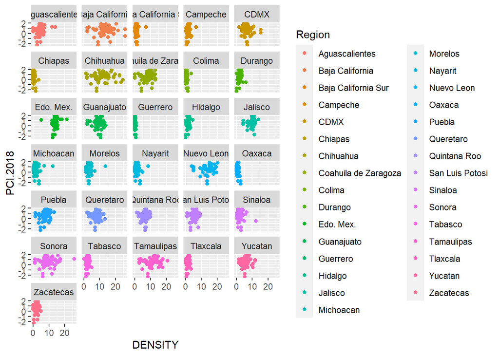

```r
p+facet_wrap(~Region, ncol=5)
```

Facet_wrap (recomendado con una variable)

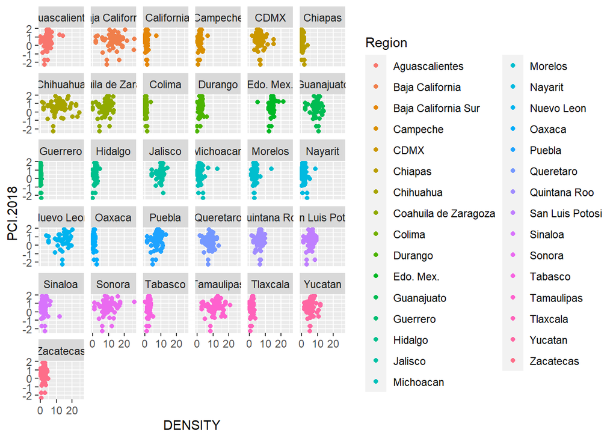

```r
p+facet_wrap(~Region)
```

Manipulando número de filas

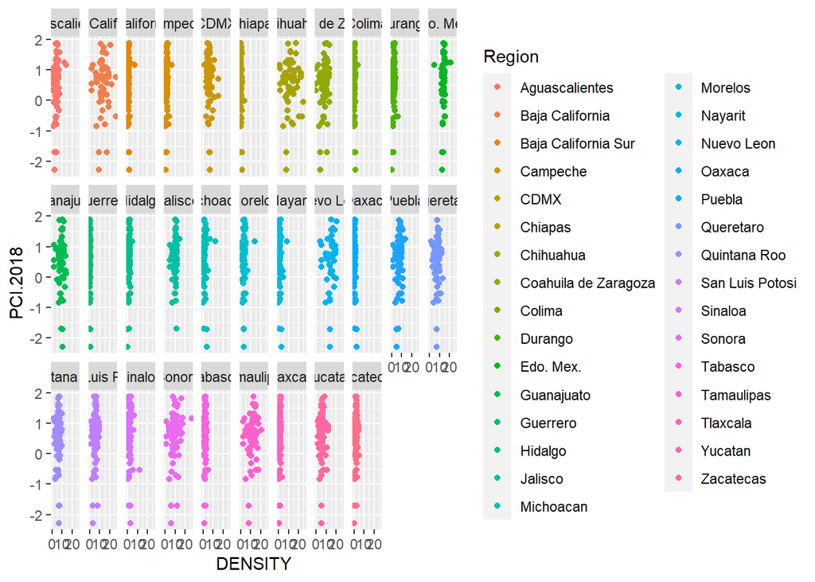

```r
p+facet_wrap(~Region, nrow=3)
```

—————————-FIN LABORATORIO 20——————————